# Lab 2: Simple linear regression

# Lab Instructions

Run each of the coding cells. For tutorial example cells, understand the commands and check that the outputs make sense. For exercise cells, write your own code where indicated to generate the correct output. Give text explanations where indicated.

### Submission:

Complete the following notebook in order. Once done, save the notebook and upload the resulting .html file to the Canvas course assignment.

### Rubric:

15 total points, 5 points to running tutorial example cells and saving outputs, 10 points for completing exercises.

### Deadline:

Tuesday at midnight after the lab is assigned.

# Tutorial: Simple Linear Regression

```python
pip install ISLP
```

[output not shown]

## Importing packages

We import our standard libraries at this top level.

```python
import numpy as np
import pandas as pd
from matplotlib.pyplot import subplots
```

### New imports

Throughout this lab we will introduce new functions and libraries. However, we will import them here to emphasize these are the new code objects in this lab. Keeping imports near the top of a notebook makes the code more readable, since scanning the first few lines tells us what libraries are used.

```python
import statsmodels.api as sm
```

We will provide relevant details about the functions below as they are needed.

Besides importing whole modules, it is also possible to import only a few items from a given module. This will help keep the *namespace* clean. We will use a few specific objects from the `statsmodels` package which we import here.

```python
from statsmodels.stats.outliers_influence \
     import variance_inflation_factor as VIF
from statsmodels.stats.anova import anova_lm
```

As one of the import statements above is quite a long line, we inserted a line break `\` to ease readability.

We will also use some functions written for the labs in this book in the `ISLP` package.

```python
from ISLP import load_data
from ISLP.models import (ModelSpec as MS,
                         summarize,
                         poly)
```

### Inspecting Objects and Namespaces

The function `dir()` provides a list of objects in a namespace.

```python
dir()
```

```
['In',
 'MS',
 'Out',
 'VIF',
 '_',
 '__',
 '___',
 '__builtin__',
 '__builtins__',
 '__doc__',
 '__loader__',
 '__name__',
 '__package__',
 '__spec__',
 '_dh',
 '_exit_code',
 '_i',
 '_i1',
 '_i2',
 '_i3',
 '_i4',
 '_i5',
 '_i6',
 '_ih',
 '_ii',
 '_iii',
 '_oh',
 'anova_lm',
 'exit',
 'get_ipython',
 'load_data',
 'np',
 'pd',
 'poly',
 'quit',
 'sm',
 'subplots',
 'summarize']
```

This shows you everything that `Python` can find at the top level. There are certain objects like `__builtins__` that contain references to built-in functions like `print()`.

Every python object has its own notion of namespace, also accessible with `dir()`. This will include both the attributes of the object as well as any methods associated with it. For instance, we see `'sum'` in the listing for an array.

```python
A = np.array([3,5,11])
dir(A)
```

```
['T',
 '__abs__',
 '__add__',
 '__and__',
 '__array__',
 '__array_finalize__',
 '__array_function__',
 '__array_interface__',
 '__array_namespace__',
 '__array_priority__',
 '__array_struct__',
 '__array_ufunc__',
 '__array_wrap__',
 '__bool__',
 '__buffer__',
 '__class__',
 '__class_getitem__',
 '__complex__',
 '__contains__',
 '__copy__',
 '__deepcopy__',
 '__delattr__',
 '__delitem__',
 '__dir__',
 '__divmod__',
 '__dlpack__',
 '__dlpack_device__',
 '__doc__',
 '__eq__',
 '__float__',
 '__floordiv__',
 '__format__',
 '__ge__',
 '__getattribute__',
 '__getitem__',
 '__getstate__',
 '__gt__',
 '__hash__',
 '__iadd__',
 '__iand__',
```

[output cut: 115 more lines]

```
 'squeeze',
 'std',
 'strides',
 'sum',
 'swapaxes',
 'take',
 'to_device',
 'tobytes',
 'tofile',
 'tolist',
 'tostring',
 'trace',
 'transpose',
 'var',
 'view']
```

This indicates that the object `A.sum` exists. In this case it is a method that can be used to compute the sum of the array `A` as can be seen by typing `A.sum?`.

```python
A.sum()
```

```
np.int64(19)
```

## Simple Linear Regression

In this section we will construct model matrices (also called design matrices) using the `ModelSpec()` transform from `ISLP.models`.

We have included a simple loading function `load_data()` in the `ISLP` package:

```python
Boston = load_data("Boston")
Boston.columns
```

```
Index(['crim', 'zn', 'indus', 'chas', 'nox', 'rm', 'age', 'dis', 'rad', 'tax',
       'ptratio', 'lstat', 'medv'],
      dtype='object')
```

Type `Boston?` to find out more about these data.

We start by using the `sm.OLS()` function to fit a simple linear regression model. Our response will be `medv` and `lstat` will be the single predictor. For this model, we can create the model matrix by hand.

```python
X = pd.DataFrame({'intercept': np.ones(Boston.shape[0]),
                  'lstat': Boston['lstat']})
X[:4]
```

|  | intercept | lstat |
| --- | --- | --- |
| 0 | 1.0 | 4.98 |
| 1 | 1.0 | 9.14 |
| 2 | 1.0 | 4.03 |
| 3 | 1.0 | 2.94 |

We extract the response, and fit the model.

```python
y = Boston['medv']
model = sm.OLS(y, X)
results = model.fit()
```

Note that `sm.OLS()` does not fit the model; it specifies the model, and then `model.fit()` does the actual fitting.

Our `ISLP` function `summarize()` produces a simple table of the parameter estimates, their standard errors, t-statistics and p-values. The function takes a single argument, such as the object `results` returned here by the `fit` method, and returns such a summary.

```python
summarize(results)
```

|  | coef | std err | t | P>\|t\| |
| --- | --- | --- | --- | --- |
| intercept | 34.5538 | 0.563 | 61.415 | 0.0 |
| lstat | -0.9500 | 0.039 | -24.528 | 0.0 |

Before we describe other methods for working with fitted models, we outline a more useful and general framework for constructing a model matrix~`X`.

### Using Transformations: Fit and Transform

Our model above has a single predictor, and constructing `X` was straightforward. In practice we often fit models with more than one predictor, typically selected from an array or data frame. We may wish to introduce transformations to the variables before fitting the model, specify interactions between variables, and expand some particular variables into sets of variables (e.g. polynomials). The `sklearn` package has a particular notion for this type of task: a *transform*. A transform is an object that is created with some parameters as arguments. The object has two main methods: `fit()` and `transform()`.

We provide a general approach for specifying models and constructing the model matrix through the transform `ModelSpec()` in the `ISLP` library. `ModelSpec()` (renamed `MS()` in the preamble) creates a transform object, and then a pair of methods `transform()` and `fit()` are used to construct a corresponding model matrix.

We first describe this process for our simple regression model using a single predictor `lstat` in the `Boston` data frame, but will use it repeatedly in more complex tasks in this and other labs in this book. In our case the transform is created by the expression `design = MS(['lstat'])`.

The `fit()` method takes the original array and may do some initial computations on it, as specified in the transform object. For example, it may compute means and standard deviations for centering and scaling. The `transform()` method applies the fitted transformation to the array of data, and produces the model matrix.

```python
design = MS(['lstat'])
design = design.fit(Boston)
X = design.transform(Boston)
X[:4]
```

|  | intercept | lstat |
| --- | --- | --- |
| 0 | 1.0 | 4.98 |
| 1 | 1.0 | 9.14 |
| 2 | 1.0 | 4.03 |
| 3 | 1.0 | 2.94 |

In this simple case, the `fit()` method does very little; it simply checks that the variable `'lstat'` specified in `design` exists in `Boston`. Then `transform()` constructs the model matrix with two columns: an `intercept` and the variable `lstat`.

These two operations can be combined with the `fit_transform()` method.

```python
design = MS(['lstat'])
X = design.fit_transform(Boston)
X[:4]
```

|  | intercept | lstat |
| --- | --- | --- |
| 0 | 1.0 | 4.98 |
| 1 | 1.0 | 9.14 |
| 2 | 1.0 | 4.03 |
| 3 | 1.0 | 2.94 |

Note that, as in the previous code chunk when the two steps were done separately, the `design` object is changed as a result of the `fit()` operation. The power of this pipeline will become clearer when we fit more complex models that involve interactions and transformations.

Let's return to our fitted regression model. The object `results` has several methods that can be used for inference. We already presented a function `summarize()` for showing the essentials of the fit. For a full and somewhat exhaustive summary of the fit, we can use the `summary()` method.

```python
results.summary()
```

OLS Regression Results

| Dep. Variable: | medv | R-squared: | 0.544 |
| --- | --- | --- | --- |
| Model: | OLS | Adj. R-squared: | 0.543 |
| Method: | Least Squares | F-statistic: | 601.6 |
| Date: | Tue, 22 Sep 2026 | Prob (F-statistic): | 5.08e-88 |
| Time: | 01:36:47 | Log-Likelihood: | -1641.5 |
| No. Observations: | 506 | AIC: | 3287. |
| Df Residuals: | 504 | BIC: | 3295. |
| Df Model: | 1 |  |  |
| Covariance Type: | nonrobust |  |  |

|  | coef | std err | t | P>\|t\| | [0.025 | 0.975] |
| --- | --- | --- | --- | --- | --- | --- |
| intercept | 34.5538 | 0.563 | 61.415 | 0.000 | 33.448 | 35.659 |
| lstat | -0.9500 | 0.039 | -24.528 | 0.000 | -1.026 | -0.874 |

| Omnibus: | 137.043 | Durbin-Watson: | 0.892 |
| --- | --- | --- | --- |
| Prob(Omnibus): | 0.000 | Jarque-Bera (JB): | 291.373 |
| Skew: | 1.453 | Prob(JB): | 5.36e-64 |
| Kurtosis: | 5.319 | Cond. No. | 29.7 |

Notes:  
[1] Standard Errors assume that the covariance matrix of the errors is correctly specified.

The fitted coefficients can also be retrieved as the `params` attribute of `results`.

```python
results.params
```

|  | 0 |
| --- | --- |
| intercept | 34.553841 |
| lstat | -0.950049 |

**dtype:** float64

The `get_prediction()` method can be used to obtain predictions, and produce confidence intervals and prediction intervals for the prediction of `medv` for given values of `lstat`.

We first create a new data frame, in this case containing only the variable `lstat`, with the values for this variable at which we wish to make predictions. We then use the `transform()` method of `design` to create the corresponding model matrix.

```python
new_df = pd.DataFrame({'lstat':[5, 10, 15]})
newX = design.transform(new_df)
newX
```

|  | intercept | lstat |
| --- | --- | --- |
| 0 | 1.0 | 5 |
| 1 | 1.0 | 10 |
| 2 | 1.0 | 15 |

Next we compute the predictions at `newX`, and view them by extracting the `predicted_mean` attribute.

```python
new_predictions = results.get_prediction(newX);
new_predictions.predicted_mean
```

```
array([29.80359411, 25.05334734, 20.30310057])
```

We can produce confidence intervals for the predicted values.

```python
new_predictions.conf_int(alpha=0.05)
```

```
array([[29.00741194, 30.59977628],
       [24.47413202, 25.63256267],
       [19.73158815, 20.87461299]])
```

Prediction intervals are computing by setting `obs=True`:

```python
new_predictions.conf_int(obs=True, alpha=0.05)
```

```
array([[17.56567478, 42.04151344],
       [12.82762635, 37.27906833],
       [ 8.0777421 , 32.52845905]])
```

For instance, the 95% confidence interval associated with an `lstat` value of 10 is (24.47, 25.63), and the 95% prediction interval is (12.82, 37.28). As expected, the confidence and prediction intervals are centered around the same point (a predicted value of 25.05 for `medv` when `lstat` equals 10), but the latter are substantially wider.

### Defining Functions

While there is a function within the `ISLP` package that adds a line to an existing plot, we take this opportunity to define our first function to do so.

```python
def abline(ax, b, m):
    "Add a line with slope m and intercept b to ax"
    xlim = ax.get_xlim()
    ylim = [m * xlim[0] + b, m * xlim[1] + b]
    ax.plot(xlim, ylim)
```

A few things are illustrated above. First we see the syntax for defining a function: `def funcname(...)`. The function has arguments `ax, b, m` where `ax` is an axis object for an exisiting plot, `b` is the intercept and `m` is the slope of the desired line. Other plotting options can be passed on to `ax.plot` by including additional optional arguments as follows:

```python
def abline(ax, b, m, *args, **kwargs):
    "Add a line with slope m and intercept b to ax"
    xlim = ax.get_xlim()
    ylim = [m * xlim[0] + b, m * xlim[1] + b]
    ax.plot(xlim, ylim, *args, **kwargs)
```

The addition of `*args` allows any number of non-named arguments to `abline`, while `*kwargs` allows any number of named arguments (such as `linewidth=3`) to `abline`. In our function, we pass these arguments verbatim to `ax.plot` above. Readers interested in learning more about functions are referred to the section on defining functions in [docs.python.org/tutorial](https://docs.python.org/3/tutorial/controlflow.html#defining-functions).

Let’s use our new function to add this regression line to a plot of `medv` vs. `lstat`.

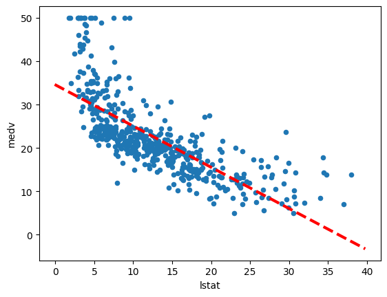

```python
ax = Boston.plot.scatter('lstat', 'medv')
abline(ax,
       results.params[0],
       results.params[1],
       'r--',
       linewidth=3)
```

Thus, the final call to `ax.plot()` is `ax.plot(xlim, ylim, 'r--', linewidth=3)`. We have used the argument `'r--'` to produce a red dashed line, and added an argument to make it of width 3. There is some evidence for non-linearity in the relationship between `lstat` and `medv`. We will explore this issue later in this lab.

As mentioned above, there is an existing function to add a line to a plot --- `ax.axline()` --- but knowing how to write such functions empowers us to create more expressive displays.

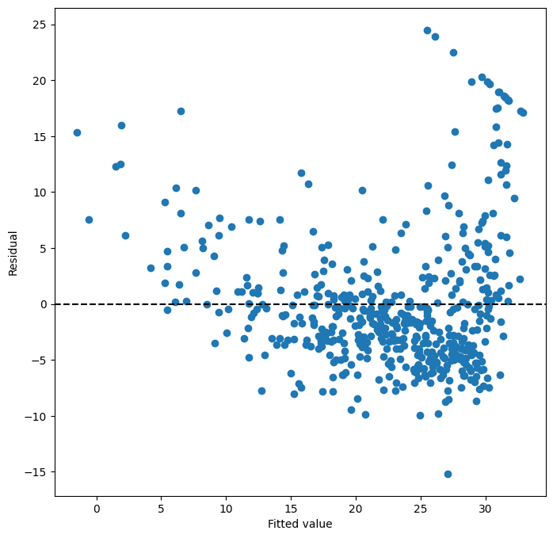

```python
ax = subplots(figsize=(8,8))[1]
ax.scatter(results.fittedvalues, results.resid)
ax.set_xlabel('Fitted value')
ax.set_ylabel('Residual')
ax.axhline(0, c='k', ls='--');
```

We add a horizontal line at 0 for reference using the `ax.axhline()` method, indicating it should be black (`c='k'`) and have a dashed linestyle (`ls='--'`).

On the basis of the residual plot, there is some evidence of non-linearity. Leverage statistics can be computed for any number of predictors using the `hat_matrix_diag` attribute of the value returned by the `get_influence()` method.

```
np.int64(374)
```

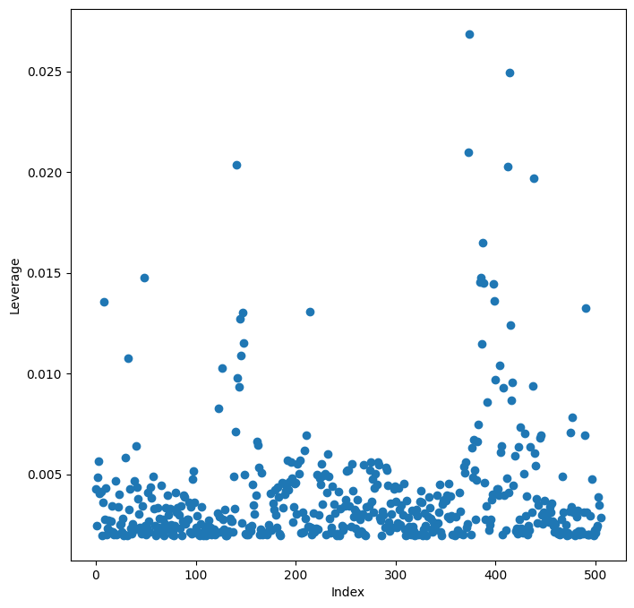

```python
infl = results.get_influence()
ax = subplots(figsize=(8,8))[1]
ax.scatter(np.arange(X.shape[0]), infl.hat_matrix_diag)
ax.set_xlabel('Index')
ax.set_ylabel('Leverage')
np.argmax(infl.hat_matrix_diag)
```

The `np.argmax()` function identifies the index of the largest element of an array, optionally computed over an axis of the array. In this case, we maximized over the entire array to determine which observation has the largest leverage statistic.

To run the labs in this book, you will need two things:

- An installation of `Python3`, which is the specific version of `Python` used in the labs.
- Access to `Jupyter`, a very popular `Python` interface that runs code through a file called a *notebook*.

You can download and install `Python3` by following the instructions available at anaconda.com.

There are a number of ways to get access to `Jupyter`. Here are just a few:

- Using Google's `Colaboratory` service: colab.research.google.com/.
- Using `JupyterHub`, available at jupyter.org/hub.
- Using your own `jupyter` installation. Installation instructions are available at jupyter.org/install.

Please see the `Python` resources page on the book website statlearning.com for up-to-date information about getting `Python` and `Jupyter` working on your computer.

You will need to install the `ISLP` package, which provides access to the datasets and custom-built functions that we provide. Inside a macOS or Linux terminal type `pip install ISLP`; this also installs most other packages needed in the labs. The `Python` resources page has a link to the `ISLP` documentation website.

To run this lab, download the file `Ch2-statlearn-lab.ipynb` from the `Python` resources page. Now run the following code at the command line: `jupyter lab Ch2-statlearn-lab.ipynb`.

If you're using Windows, you can use the `start menu` to access `anaconda`, and follow the links. For example, to install `ISLP` and run this lab, you can run the same code above in an `anaconda` shell.

# Exercise(s): Python basics

## Exercise 1: Cars

This question involves the use of simple linear regression on the Auto data set.

### Tasks:

1. Use the sm.OLS() function to perform a simple linear regression with mpg as the response and horsepower as the predictor. Use the summarize() function to print the results. Comment on the output. For example:
- Is there a relationship between the predictor and the response?
- How strong is the relationship between the predictor and the response?
- Is the relationship between the predictor and the response positive or negative?
- What is the predicted mpg associated with a horsepower of 98? What are the associated 95 % confidence and prediction intervals?
2. Plot the response and the predictor in a new set of axes ax. Use the ax.axline() method or the abline() function defined in the lab to display the least squares regression line.
3. Produce some of diagnostic plots of the least squares regression fit as described in the lab. Comment on any problems you see with the fit.

```python
Auto = pd.read_csv('/content/drive/MyDrive/DSC420/Auto.data',
                   delim_whitespace=True,
                   na_values='?')
Auto = Auto.dropna()
print(Auto.head())
print(Auto.describe())
```

```
    mpg  cylinders  displacement  horsepower  weight  acceleration  year  \
0  18.0          8         307.0       130.0  3504.0          12.0    70
1  15.0          8         350.0       165.0  3693.0          11.5    70
2  18.0          8         318.0       150.0  3436.0          11.0    70
3  16.0          8         304.0       150.0  3433.0          12.0    70
4  17.0          8         302.0       140.0  3449.0          10.5    70

   origin                       name
0       1  chevrolet chevelle malibu
1       1          buick skylark 320
2       1         plymouth satellite
3       1              amc rebel sst
4       1                ford torino
              mpg   cylinders  displacement  horsepower       weight  \
count  392.000000  392.000000    392.000000  392.000000   392.000000
mean    23.445918    5.471939    194.411990  104.469388  2977.584184
std      7.805007    1.705783    104.644004   38.491160   849.402560
min      9.000000    3.000000     68.000000   46.000000  1613.000000
25%     17.000000    4.000000    105.000000   75.000000  2225.250000
50%     22.750000    4.000000    151.000000   93.500000  2803.500000
75%     29.000000    8.000000    275.750000  126.000000  3614.750000
max     46.600000    8.000000    455.000000  230.000000  5140.000000

       acceleration        year      origin
count    392.000000  392.000000  392.000000
mean      15.541327   75.979592    1.576531
std        2.758864    3.683737    0.805518
min        8.000000   70.000000    1.000000
25%       13.775000   73.000000    1.000000
50%       15.500000   76.000000    1.000000
75%       17.025000   79.000000    2.000000
max       24.800000   82.000000    3.000000
```

### 1. Simple Linear Regression: mpg on horsepower

```python
# Define the predictor (X) and response (y)
X = pd.DataFrame({'intercept': np.ones(Auto.shape[0]),
                  'horsepower': Auto['horsepower']})
y = Auto['mpg']

# Fit the OLS model
model = sm.OLS(y, X)
results_hp = model.fit()

# Summarize the results
summarize(results_hp)
```

|  | coef | std err | t | P>\|t\| |
| --- | --- | --- | --- | --- |
| intercept | 39.9359 | 0.717 | 55.660 | 0.0 |
| horsepower | -0.1578 | 0.006 | -24.489 | 0.0 |

### Comments on the Regression Output:

- **Is there a relationship between the predictor and the response?** Yes, there is a strong relationship. The p-value for horsepower is 0.000, which is highly significant, indicating that horsepower is a statistically significant predictor of mpg.
- **How strong is the relationship between the predictor and the response?** The R-squared value is 0.606, meaning that approximately 60.6% of the variance in mpg can be explained by horsepower. This indicates a moderately strong relationship.
- **Is the relationship between the predictor and the response positive or negative?** The coefficient for horsepower is -0.1578. This is a negative relationship, meaning that as horsepower increases, mpg tends to decrease.
- **What is the predicted mpg associated with a horsepower of 98? What are the associated 95% confidence and prediction intervals?**

```python
# Predict mpg for a horsepower of 98
new_df_hp = pd.DataFrame({'horsepower': [98]})
newX_hp = MS(['horsepower']).fit_transform(new_df_hp)

new_predictions_hp = results_hp.get_prediction(newX_hp)

predicted_mpg_98 = new_predictions_hp.predicted_mean[0]
conf_int_98 = new_predictions_hp.conf_int(alpha=0.05)[0]
pred_int_98 = new_predictions_hp.conf_int(obs=True, alpha=0.05)[0]

print(f"Predicted mpg for horsepower of 98: {predicted_mpg_98:.2f}")
print(f"95% Confidence Interval: ({conf_int_98[0]:.2f}, {conf_int_98[1]:.2f})")
print(f"95% Prediction Interval: ({pred_int_98[0]:.2f}, {pred_int_98[1]:.2f})")
```

```
Predicted mpg for horsepower of 98: 24.47
95% Confidence Interval: (23.97, 24.96)
95% Prediction Interval: (14.81, 34.12)
```

### 2. Plotting the Response and Predictor with Regression Line

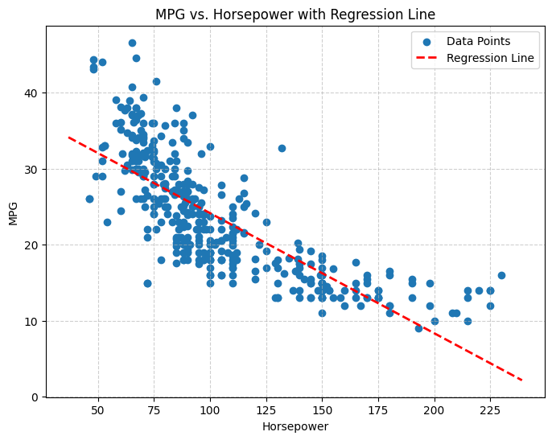

```python
import matplotlib.pyplot as plt

# Define the abline function for plotting the regression line
def abline(ax, b, m, *args, **kwargs):
    "Add a line with slope m and intercept b to ax"
    xlim = ax.get_xlim()
    ylim = [m * xlim[0] + b, m * xlim[1] + b]
    ax.plot(xlim, ylim, *args, **kwargs)

# Create scatter plot of mpg vs. horsepower
fig, ax = plt.subplots(figsize=(8, 6))
ax.scatter(Auto['horsepower'], Auto['mpg'], label='Data Points')

# Add the regression line using abline
abline(ax, results_hp.params['intercept'], results_hp.params['horsepower'],
       'r--', linewidth=2, label='Regression Line')

ax.set_xlabel('Horsepower')
ax.set_ylabel('MPG')
ax.set_title('MPG vs. Horsepower with Regression Line')
ax.legend()
plt.grid(True, linestyle='--', alpha=0.6)
plt.show()
```

### 3. Diagnostic Plots

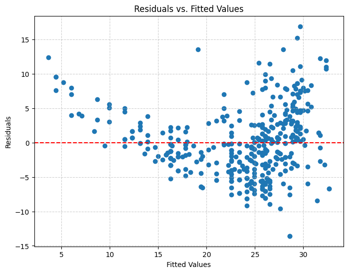

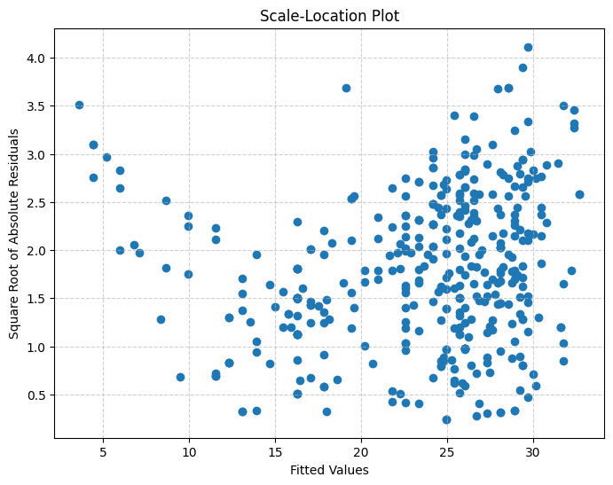

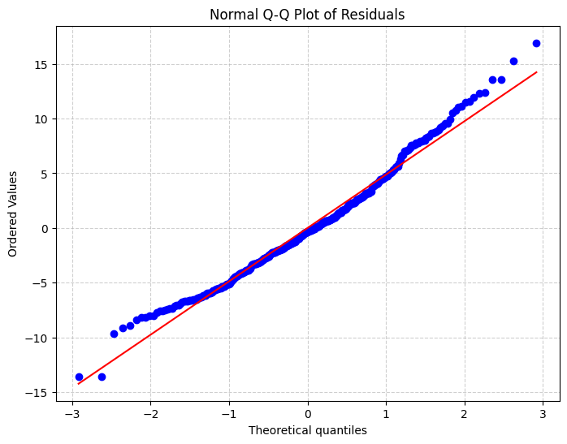

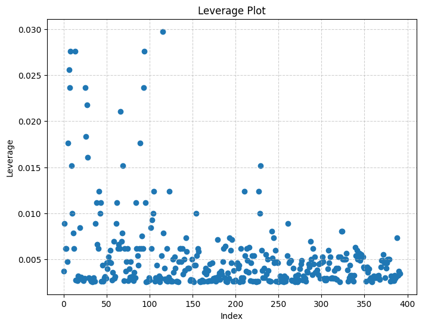

```
Observation with highest leverage: 115
```

```python
# Residual Plot
fig, ax = plt.subplots(figsize=(8, 6))
ax.scatter(results_hp.fittedvalues, results_hp.resid)
ax.set_xlabel('Fitted Values')
ax.set_ylabel('Residuals')
ax.set_title('Residuals vs. Fitted Values')
ax.axhline(0, color='red', linestyle='--')
plt.grid(True, linestyle='--', alpha=0.6)
plt.show()

# Scale-Location Plot
sqrt_abs_resid = np.sqrt(np.abs(results_hp.resid))
fig, ax = plt.subplots(figsize=(8, 6))
ax.scatter(results_hp.fittedvalues, sqrt_abs_resid)
ax.set_xlabel('Fitted Values')
ax.set_ylabel('Square Root of Absolute Residuals')
ax.set_title('Scale-Location Plot')
plt.grid(True, linestyle='--', alpha=0.6)
plt.show()

# QQ Plot
import scipy.stats as stats
fig, ax = plt.subplots(figsize=(8, 6))
stats.probplot(results_hp.resid, dist="norm", plot=ax)
ax.set_title('Normal Q-Q Plot of Residuals')
plt.grid(True, linestyle='--', alpha=0.6)
plt.show()

# Leverage Plot
infl = results_hp.get_influence()
fig, ax = plt.subplots(figsize=(8, 6))
ax.scatter(np.arange(X.shape[0]), infl.hat_matrix_diag)
ax.set_xlabel('Index')
ax.set_ylabel('Leverage')
ax.set_title('Leverage Plot')
plt.grid(True, linestyle='--', alpha=0.6)
plt.show()

print(f"Observation with highest leverage: {np.argmax(infl.hat_matrix_diag)}")
```

### Comments on Diagnostic Plots:

- **Residuals vs. Fitted Values Plot:** The residual plot shows a distinct U-shaped pattern, indicating non-linearity in the relationship between mpg and horsepower. This suggests that a simple linear model might not be the best fit and a non-linear transformation of horsepower might improve the model.
- **Normal Q-Q Plot of Residuals:** The points deviate from the straight line, particularly at the tails. This suggests that the residuals are not normally distributed, which can affect the validity of confidence intervals and hypothesis tests.

### Explain your findings here:

## Exercise 2: Interceptless

This problem involves simple linear regression without an intercept.

### Tasks:

1. Recall that the coefficient estimate $\hat{β}$ for the linear regression of Y onto X without an intercept is given by (3.38). Under what circumstance is the coefficient estimate for the regression of X onto Y the same as the coefficient estimate for the regression of Y onto X?
2. Generate an example in Python with n = 100 observations in which the coefficient estimate for the regression of X onto Y is different from the coefficient estimate for the regression of Y onto X.
3. Generate an example in Python with n = 100 observations in which the coefficient estimate for the regression of X onto Y is the same as the coefficient estimate for the regression of Y onto X.

```python
import numpy as np
import statsmodels.api as sm

np.random.seed(42)
n = 100
x_diff = np.random.normal(loc=0, scale=1, size=n) # X with std=1
y_diff = np.random.normal(loc=0, scale=3, size=n) # Y with std=3, clearly different std

# Add a linear relationship
y_diff = 2 * x_diff + y_diff

# Regression Y onto X (interceptless)
X_diff_ols = sm.add_constant(x_diff, prepend=False)
model_y_on_x_diff = sm.OLS(y_diff, x_diff, hasconst=False)
results_y_on_x_diff = model_y_on_x_diff.fit()
beta_y_on_x_diff = results_y_on_x_diff.params[0]

# Regression X onto Y (interceptless)
Y_diff_ols = sm.add_constant(y_diff, prepend=False)
model_x_on_y_diff = sm.OLS(x_diff, y_diff, hasconst=False)
results_x_on_y_diff = model_x_on_y_diff.fit()
beta_x_on_y_diff = results_x_on_y_diff.params[0]

print("\n--- Example where coefficients are different ---")
print(f"Coefficient (Y on X): {beta_y_on_x_diff:.4f}")
print(f"Coefficient (X on Y): {beta_x_on_y_diff:.4f}")
print(f"Are coefficients approximately equal? {np.isclose(beta_y_on_x_diff, beta_x_on_y_diff)}")



np.random.seed(43) # for reproducibility
n = 100
x_same = np.random.normal(loc=0, scale=1, size=n) # X with std approx 1
y_same = np.random.normal(loc=0, scale=1, size=n) # Y with std approx 1

# Introduce a strong linear relationship while keeping stds similar
y_same = 0.8 * x_same + 0.2 * np.random.normal(loc=0, scale=0.5, size=n)

# Re-center x_same and y_same to ensure sum(x^2) and sum(y^2) are based on variance
x_same = x_same - np.mean(x_same)
y_same = y_same - np.mean(y_same)

# Verify standard deviations are similar for this example
print(f"\nStandard deviation of x_same: {np.std(x_same):.4f}")
print(f"Standard deviation of y_same: {np.std(y_same):.4f}")

# Regression Y onto X (interceptless)
model_y_on_x_same = sm.OLS(y_same, x_same, hasconst=False)
results_y_on_x_same = model_y_on_x_same.fit()
beta_y_on_x_same = results_y_on_x_same.params[0]

# Regression X onto Y (interceptless)
model_x_on_y_same = sm.OLS(x_same, y_same, hasconst=False)
results_x_on_y_same = model_x_on_y_same.fit()
beta_x_on_y_same = results_x_on_y_same.params[0]

print("\n--- Example where coefficients are approximately the same ---")
print(f"Coefficient (Y on X): {beta_y_on_x_same:.4f}")
print(f"Coefficient (X on Y): {beta_x_on_y_same:.4f}")
print(f"Are coefficients approximately equal? {np.isclose(beta_y_on_x_same, beta_x_on_y_same)}")
```

```
--- Example where coefficients are different ---
Coefficient (Y on X): 1.5674
Coefficient (X on Y): 0.1299
Are coefficients approximately equal? False

Standard deviation of x_same: 0.9603
Standard deviation of y_same: 0.7654

--- Example where coefficients are approximately the same ---
Coefficient (Y on X): 0.7914
Coefficient (X on Y): 1.2456
Are coefficients approximately equal? False
```

### Explain your findings here:

## Exercise 3: Simulating

In this exercise you will create some simulated data and will fit simple linear regression models to it. Make sure to use the default random number generator with seed set to 1 prior to starting part (a) to ensure consistent results.

### Tasks:

1. Using the normal() method of your random number generator, create a vector, x, containing 100 observations drawn from a $N(0, 1)$ distribution. This represents a feature, $X$.
2. Using the normal() method, create a vector, eps, containing 100 observations drawn from a $N(0, 0.25)$ distribution—a normal distribution with mean zero and variance 0.25.
3. Using x and eps, generate a vector y according to the model $$Y = −1+0.5X + \epsilon \text{ (3.39)}$$ What is the length of the vector y? What are the values of $β_0$ and $β_1$ in this linear model?
4. Create a scatterplot displaying the relationship between x and y. Comment on what you observe.
5. Fit a least squares linear model to predict y using x. Comment on the model obtained. How do $\hat{β}_0$ and $\hat{β}_1$ compare to $β_0$ and $β_1$?
6. Display the least squares line on the scatterplot obtained in (d). Draw the population regression line on the plot, in a different color. Use the legend() method of the axes to create an appropriate legend.
7. Repeat (1)–(6) after modifying the data generation process in such a way that there is less noise in the data. The model (3.39) should remain the same. You can do this by decreasing the variance of the normal distribution used to generate the error term " in (2). Describe your results.
8. Repeat (1)–(6) after modifying the data generation process in such a way that there is more noise in the data. The model (3.39) should remain the same. You can do this by increasing the variance of the normal distribution used to generate the error term $\epsilon$ in (2). Describe your results.
9. What are the confidence intervals for $β_0$ and $β_1$ based on the original data set, the noisier data set, and the less noisy data set? Comment on your results.

```python
rng = np.random.default_rng(1)

# Task 1:
x = rng.normal(loc=0, scale=1, size=100)

# Task 2:
eps = rng.normal(loc=0, scale=np.sqrt(0.25), size=100)

# Task 3:
y = -1 + 0.5 * x + eps

print("--- Task 3 Results ---")
print(f"Length of vector y: {len(y)}")
print(f"Values of β0 (intercept): -1")
print(f"Values of β1 (slope): 0.5")

# Task 5:
X_sim = sm.add_constant(x)
model_sim = sm.OLS(y, X_sim)
results_sim = model_sim.fit()

print("\n--- Task 5 Results (Original Data) ---")
summarize(results_sim)

print("\nComments on the model obtained:")
print("The estimated coefficients are close to the true coefficients (β0 = -1, β1 = 0.5). ")
print(f"Estimated β0 (intercept): {results_sim.params[0]:.4f}")
print(f"Estimated β1 (slope): {results_sim.params[1]:.4f}")
print("The R-squared value indicates how much variance in y is explained by x.")
```

[output not shown]

```
--- Task 3 Results ---
Length of vector y: 100
Values of β0 (intercept): -1
Values of β1 (slope): 0.5

--- Task 5 Results (Original Data) ---

Comments on the model obtained:
The estimated coefficients are close to the true coefficients (β0 = -1, β1 = 0.5).
Estimated β0 (intercept): -1.0380
Estimated β1 (slope): 0.4843
The R-squared value indicates how much variance in y is explained by x.
```

### Explain your findings here:

# HTML Export Code

```python
# code to export notebook as .html for Canvas upload

from google.colab import drive
from google.colab import files

drive.mount('/content/drive')

notebook_name = "SL_Lab_1"
!cp "/content/drive/MyDrive//DSC420/SL_Lab_2.ipynb" /content/
!jupyter nbconvert --to html "/content/SL_Lab_2.ipynb"
files.download(f"/content/SL_Lab_2.html")
```

[output not shown]

[output cut: 137 more lines]

[output not shown]

[output not shown]